# Princing Pain

Author

Gaston Sanchez

Published

May 21, 2025

# 1 Description

The data visualization of this module is based on the following Wall Street Journal’s article by Rachel Wolfe and Rachel Louise Ensign (March 12, 2024):

**We Still Don’t Believe How Much Things Cost**

https://www.wsj.com/economy/consumers/grocery-prices-inflation-coffee-milk-903aead6

[figure not shown]

February 2024 prices for select products, and their change from February 2020

## 1.1 Details (datasheet)

- **Topic(s)**:
  - Economics
  - U.S.
  - Inflation
- **Data**:
  - Size: small data
  - Format: R vectors and data.frame
- **Graphic**:
  - Type: bar chart
  - Styles: ggplot, interactive ggiraph
  - Interactive: no

## 1.2 R Packages

```r
library(tidyverse)  # ecosystem of data science packages
```

# 2 Data

The graphic that we want to replicate is the bar chart titled **Pricing Pain**. As you can tell, the data values correspond to prices for select products.

Since this is a small data set, we can input their values by hand in R. As you know, for `ggplot` convenience, the data must be in a table object such as a data.frame or a tibble. In this case we’ll use a data.frame.

```r
product = c(
  "Baby wipes", "Bleach", "Cooking Oil", "Cows milk",
  "Deodorant", "Dog food", "Eggs", "Nutrition bars",
  "Paper towels", "Potatoes", "Ramen")

price_2020 = c(4.25, 2.78, 5.22, 2.70, 4.68, 5.42, 2.35, 3.12, 5.76, 2.00, 0.62)

price_2024 = c(6.64, 4.87, 8.04, 3.26, 7.43, 8.48, 3.87, 5.67, 8.22, 2.62, 1.08)

dat = data.frame(
  "product" = product,
  "price_2020" = price_2020,
  "price_2024" = price_2024
)

dat
```

```
          product price_2020 price_2024
1      Baby wipes       4.25       6.64
2          Bleach       2.78       4.87
3     Cooking Oil       5.22       8.04
4       Cows milk       2.70       3.26
5       Deodorant       4.68       7.43
6        Dog food       5.42       8.48
7            Eggs       2.35       3.87
8  Nutrition bars       3.12       5.67
9    Paper towels       5.76       8.22
10       Potatoes       2.00       2.62
11          Ramen       0.62       1.08
```

## 2.1 Data Preparation

Based on the price of products, we have to compute the percentage change from 2020 to 2024. The following command allows us to add (`mutate`) a column `change` for this percentage change in prices:

```r
dat = dat |>
  mutate(change = (price_2024 - price_2020) / price_2020)

dat
```

```
          product price_2020 price_2024    change
1      Baby wipes       4.25       6.64 0.5623529
2          Bleach       2.78       4.87 0.7517986
3     Cooking Oil       5.22       8.04 0.5402299
4       Cows milk       2.70       3.26 0.2074074
5       Deodorant       4.68       7.43 0.5876068
6        Dog food       5.42       8.48 0.5645756
7            Eggs       2.35       3.87 0.6468085
8  Nutrition bars       3.12       5.67 0.8173077
9    Paper towels       5.76       8.22 0.4270833
10       Potatoes       2.00       2.62 0.3100000
11          Ramen       0.62       1.08 0.7419355
```

# 3 Graphs: Bar Charts

As usual, let’s go over a series of plotting rounds, starting with a default bar chart, and then gradually adding more elements, and customizing its appearance to get as close as possible to our target visualization.

## 3.1 Version 1

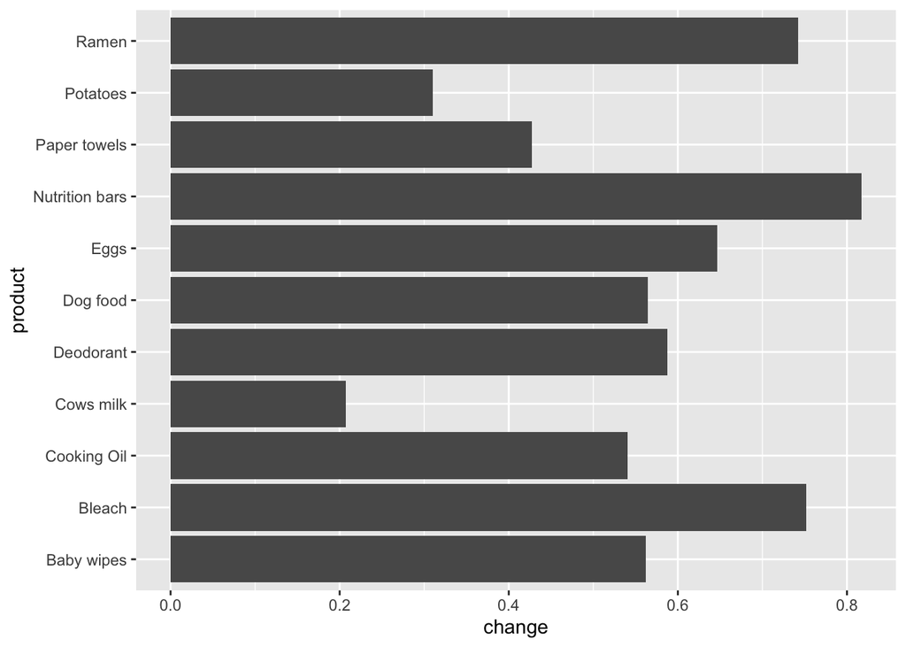

```r
# version 1: default bar chart
ggplot(dat) +
  geom_col(aes(x = change, y = product))
```

Notice that `ggplot` arranges bars in alphabetical order bottom to top. However, we need them in reversed order.

## 3.2 Version 2

To reverse the order of the labels, we have to do some data manipulations.

```r
# create "product" as an ordered R factor
product = c(
  "Baby wipes", "Bleach", "Cooking Oil", "Cows milk",
  "Deodorant", "Dog food", "Eggs", "Nutrition bars",
  "Paper towels", "Potatoes", "Ramen")

product = factor(rev(product), levels = rev(product), ordered = TRUE)

product
```

```
 [1] Ramen          Potatoes       Paper towels   Nutrition bars Eggs
 [6] Dog food       Deodorant      Cows milk      Cooking Oil    Bleach
[11] Baby wipes
11 Levels: Ramen < Potatoes < Paper towels < Nutrition bars < ... < Baby wipes
```

```r
# re-assembling data frame
price_2020 = rev(
  c(4.25, 2.78, 5.22, 2.70, 4.68, 5.42, 2.35, 3.12, 5.76, 2.00, 0.62))

price_2024 = rev(
  c(6.64, 4.87, 8.04, 3.26, 7.43, 8.48, 3.87, 5.67, 8.22, 2.62, 1.08))

dat = data.frame(
  "product" = product,
  "price_2020" = price_2020,
  "price_2024" = price_2024
)

dat = dat |>
  mutate(change = 100 * (price_2024 - price_2020) / price_2020)

dat
```

```
          product price_2020 price_2024   change
1           Ramen       0.62       1.08 74.19355
2        Potatoes       2.00       2.62 31.00000
3    Paper towels       5.76       8.22 42.70833
4  Nutrition bars       3.12       5.67 81.73077
5            Eggs       2.35       3.87 64.68085
6        Dog food       5.42       8.48 56.45756
7       Deodorant       4.68       7.43 58.76068
8       Cows milk       2.70       3.26 20.74074
9     Cooking Oil       5.22       8.04 54.02299
10         Bleach       2.78       4.87 75.17986
11     Baby wipes       4.25       6.64 56.23529
```

New bar chart with bars in the right order:

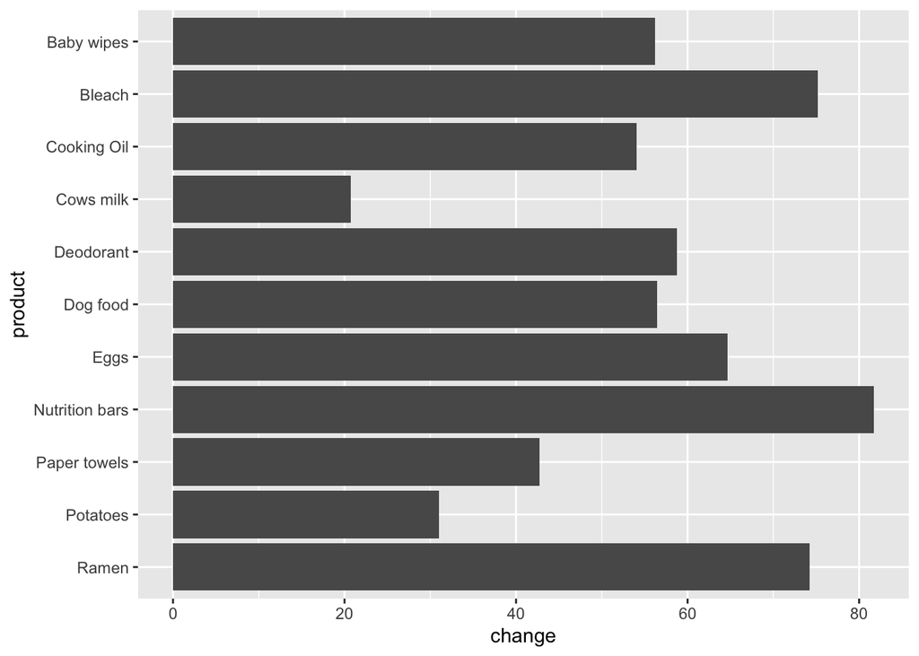

```r
# version 2: Reordering Bars
ggplot(dat) +
  geom_col(aes(x = change, y = product))
```

## 3.3 Version 3

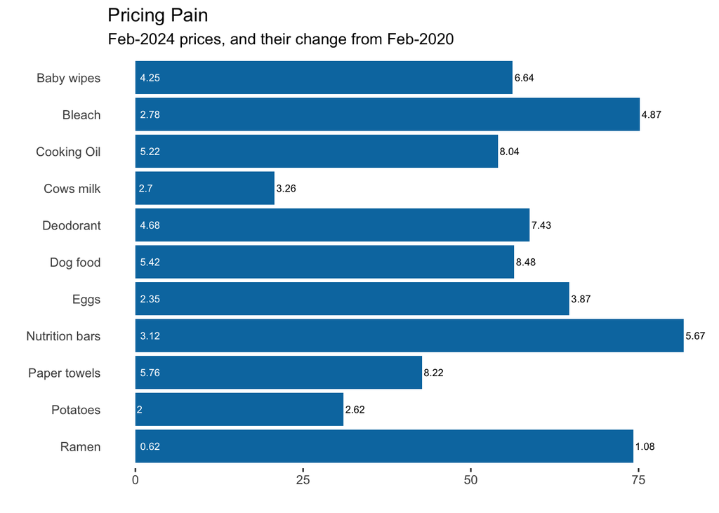

```r
# version 3: further customization
ggplot(dat) +
  geom_col(aes(x = change, y = product), fill = "#0279af") +
  scale_x_continuous(breaks = seq(0, 100, by = 25)) +
  geom_text(x = 0, aes(y = product, label = price_2020),
            hjust = -0.25, size = 2.5, color = "white") +
  geom_text(aes(x = change, y = product, label = price_2024),
            hjust = -0.1, size = 2.5, color = "black") +
  labs(title = "Pricing Pain",
       subtitle = "Feb-2024 prices, and their change from Feb-2020",
       x = "", y = "") +
  theme(axis.line = element_blank(),
        panel.background = element_blank(),
        panel.grid.major.y = element_blank(),
        panel.grid.minor.y = element_blank(),
        axis.ticks.y = element_blank())
```

## 3.4 Version 4

More data manipulation for those tiny details such as the text for the displayed labels:

```r
# improving labels
dat = dat |>
  mutate(label_2020 = paste0("$", price_2020),
         label_2024 = paste0("$", price_2024))
```

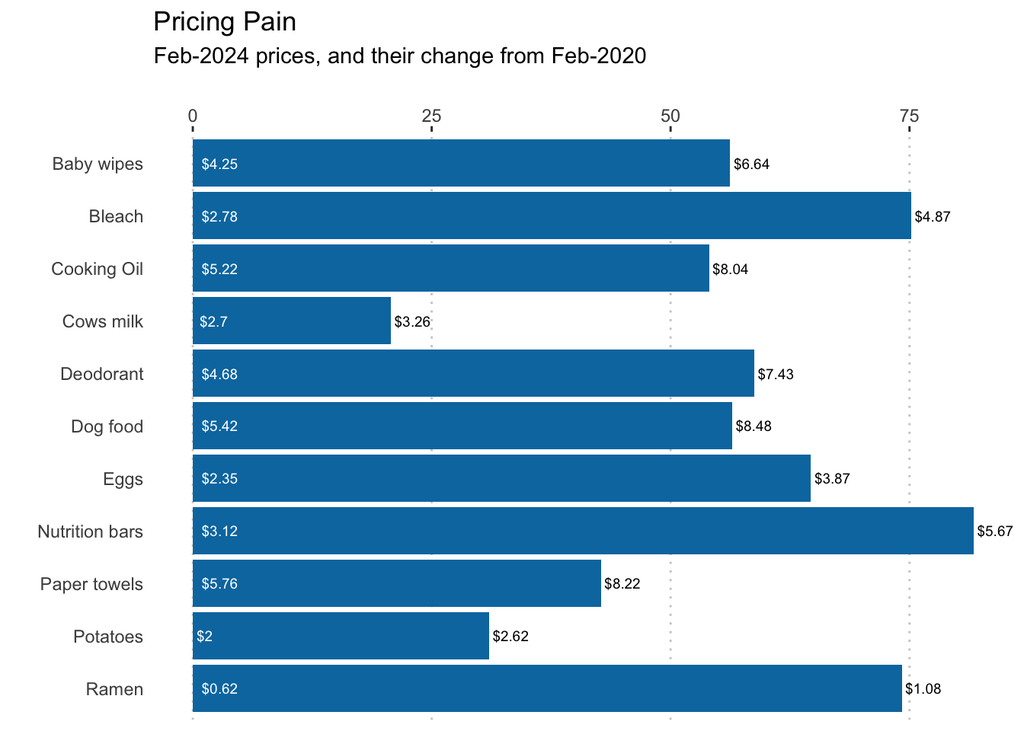

```r
# version 4
ggplot(dat) +
  theme(axis.line = element_blank(),
        panel.background = element_blank(),
        panel.grid.major.y = element_blank(),
        panel.grid.minor.y = element_blank(),
        axis.ticks.y = element_blank()) +
  geom_vline(xintercept = seq(0, 75, by = 25),
             linetype = "dotted", color = "gray80") +
  geom_col(aes(x = change, y = product), fill = "#0279af") +
  scale_x_continuous(breaks = seq(0, 100, by = 25), position = "top") +
  geom_text(x = 0, aes(y = product, label = label_2020),
            hjust = -0.25, size = 2.5, color = "white") +
  geom_text(aes(x = change, y = product, label = label_2024),
            hjust = -0.1, size = 2.5, color = "black") +
  labs(title = "Pricing Pain",
       subtitle = "Feb-2024 prices, and their change from Feb-2020",
       x = "", y = "")
```